# Introduction

This project aims to use machine learning models to help a real estate company find houses in the Nashville housing market that are overvalued and underpriced. We created and assessed models including Logistic Regression, Decision Tree, Random Forest, Gradient Boosting, and Neural Networks by cleaning and examining a dataset of recent sales. Data-driven investment decisions are made possible by these models, which offer insights into the major variables influencing property value. The findings provide practical suggestions for identifying lucrative assets and optimizing profits.

# Problem:

# You just started working for a real estate company, and they are looking to make a huge investment in the growing Nashville area. They’ve acquired a dataset about recent sales and want you to build a model to help them accurately find the best value deals when they visit next week. There is a concern that houses are going over their asking price; this dataset will help us observe that. Hint: You will have to create the dependent variable to understand whether it is over/under the price (e.g., comparing the sale price with the total value).

# Q1: Task 1:

# Use proper data cleansing techniques to ensure you have the highest quality data to model this problem. Detail your process and discuss the decisions you made to clean the data.

```python
from sklearn.model_selection import train_test_split
from sklearn.linear_model import LogisticRegression
from sklearn.metrics import accuracy_score, classification_report, confusion_matrix
from statsmodels.stats.outliers_influence import variance_inflation_factor
import seaborn as sns
import matplotlib.pyplot as plt
import pandas as pd
import numpy as np
from sklearn.tree import DecisionTreeClassifier, export_text
from sklearn.tree import plot_tree
from sklearn.ensemble import RandomForestClassifier
from sklearn.ensemble import GradientBoostingClassifier
from sklearn.preprocessing import StandardScaler

# Load the dataset
file_path = r'C:\Users\Mohit Saini\Downloads\Module 5 Assignment\Nashville_housing_data_2013_2016.csv'
nashville_data = pd.read_csv(file_path)
```

# A1: Task 1: Data Cleaning

```python
# Display summary statistics for all columns (including categorical)
print("Summary Statistics for All Columns:")
print(nashville_data.describe(include='all'))
print("\nTable 1: summary statistics for all columns (including categorical)")
```

```
Summary Statistics for All Columns:
        Unnamed: 0.1   Unnamed: 0         Parcel ID       Land Use  \
count    56636.00000  56636.00000             56636          56636
unique           NaN          NaN             48697             39
top              NaN          NaN  083 04 0K 001.00  SINGLE FAMILY
freq             NaN          NaN                 4          34268
mean     28317.50000  28317.50000               NaN            NaN
std      16349.54926  16349.54926               NaN            NaN
min          0.00000      0.00000               NaN            NaN
25%      14158.75000  14158.75000               NaN            NaN
50%      28317.50000  28317.50000               NaN            NaN
75%      42476.25000  42476.25000               NaN            NaN
max      56635.00000  56635.00000               NaN            NaN

       Property Address Suite/ Condo   # Property City   Sale Date  \
count             56477             6109         56477       56636
unique            45068             1952            14        1117
top     1212  LAUREL ST                1     NASHVILLE  2013-06-28
freq                296               55         40280         305
mean                NaN              NaN           NaN         NaN
std                 NaN              NaN           NaN         NaN
min                 NaN              NaN           NaN         NaN
25%                 NaN              NaN           NaN         NaN
50%                 NaN              NaN           NaN         NaN
75%                 NaN              NaN           NaN         NaN
max                 NaN              NaN           NaN         NaN

          Sale Price   Legal Reference  ... Building Value   Total Value  \
count   5.663600e+04             56636  ...   2.601700e+04  2.601700e+04
unique           NaN             52898  ...            NaN           NaN
top              NaN  20150511-0042855  ...            NaN           NaN
freq             NaN               116  ...            NaN           NaN
mean    3.272111e+05               NaN  ...   1.608025e+05  2.323971e+05
std     9.287425e+05               NaN  ...   2.068041e+05  2.810703e+05
min     5.000000e+01               NaN  ...   0.000000e+00  1.000000e+02
25%     1.350000e+05               NaN  ...   7.590000e+04  1.028000e+05
50%     2.054500e+05               NaN  ...   1.114000e+05  1.485000e+05
75%     3.290000e+05               NaN  ...   1.807000e+05  2.685000e+05
max     5.427806e+07               NaN  ...   1.297180e+07  1.394040e+07

```

[output cut: 14 more lines]

```
count   24159.000000  24277.000000  24146.000000
unique           NaN           NaN           NaN
top              NaN           NaN           NaN
freq             NaN           NaN           NaN
mean        3.090029      1.886106      0.283981
std         0.852942      0.961572      0.487905
min         0.000000      0.000000      0.000000
25%         3.000000      1.000000      0.000000
50%         3.000000      2.000000      0.000000
75%         3.000000      2.000000      1.000000
max        11.000000     10.000000      3.000000

[11 rows x 31 columns]

Table 1: summary statistics for all columns (including categorical)
```

# Step 1: Check for Missing Values

```python
missing_data = nashville_data.isnull().sum()
print("Number of Missing Values in Each Column:")
print(missing_data)
print("\nTable 2: Number of Missing Values in Each Column:")
```

```
Number of Missing Values in Each Column:
Unnamed: 0.1                             0
Unnamed: 0                               0
Parcel ID                                0
Land Use                                 0
Property Address                       159
Suite/ Condo   #                     50527
Property City                          159
Sale Date                                0
Sale Price                               0
Legal Reference                          0
Sold As Vacant                           0
Multiple Parcels Involved in Sale        0
Owner Name                           31375
Address                              30619
City                                 30619
State                                30619
Acreage                              30619
Tax District                         30619
Neighborhood                         30619
image                                31301
Land Value                           30619
Building Value                       30619
Total Value                          30619
Finished Area                        32470
Foundation Type                      32472
Year Built                           32471
Exterior Wall                        32471
Grade                                32471
Bedrooms                             32477
Full Bath                            32359
Half Bath                            32490
dtype: int64

Table 2: Number of Missing Values in Each Column:
```

# Step 2: Drop Columns with Excessive Missing Data

```python
columns_to_drop = ['Suite/ Condo   #', 'Owner Name', 'Address', 'City', 'State',
                   'Tax District', 'Neighborhood', 'image']  # High missing data
nashville_data_cleaned = nashville_data.drop(columns=columns_to_drop)
```

```python
print(f"Columns dropped: {columns_to_drop}")
print(f"Remaining columns: {nashville_data_cleaned.columns.tolist()}")
print("\nTable 2: Columns dropped and Remaining Columns:")
```

```
Columns dropped: ['Suite/ Condo   #', 'Owner Name', 'Address', 'City', 'State', 'Tax District', 'Neighborhood', 'image']
Remaining columns: ['Unnamed: 0.1', 'Unnamed: 0', 'Parcel ID', 'Land Use', 'Property Address', 'Property City', 'Sale Date', 'Sale Price', 'Legal Reference', 'Sold As Vacant', 'Multiple Parcels Involved in Sale', 'Acreage', 'Land Value', 'Building Value', 'Total Value', 'Finished Area', 'Foundation …

Table 2: Columns dropped and Remaining Columns:
```

# Step 3: Impute Missing Values

```python
# Fill numeric columns with the median
numeric_columns = nashville_data_cleaned.select_dtypes(include=['float64', 'int64']).columns
nashville_data_cleaned[numeric_columns] = nashville_data_cleaned[numeric_columns].fillna(
    nashville_data_cleaned[numeric_columns].median()
)
```

```python
# Fill categorical columns with the mode
categorical_columns = nashville_data_cleaned.select_dtypes(include=['object']).columns
for column in categorical_columns:
    nashville_data_cleaned[column] = nashville_data_cleaned[column].fillna(
        nashville_data_cleaned[column].mode()[0]
    )
```

# Step 4: Convert Data Types

```python
# Convert 'sale_date' to datetime
nashville_data_cleaned['Sale Date'] = pd.to_datetime(nashville_data_cleaned['Sale Date'], errors='coerce')
```

# Step 5: Create a Dependent Variable

```python
# Calculate the difference between sale price and total value
nashville_data_cleaned['sale_price_status'] = (
    nashville_data_cleaned['Sale Price'] - nashville_data_cleaned['Total Value']
)
```

# Step 6: Remove Duplicates

```python
nashville_data_cleaned = nashville_data_cleaned.drop_duplicates()
```

# Step 7: Standardize Column Names

```python
nashville_data_cleaned.columns = (
    nashville_data_cleaned.columns.str.strip().str.lower().str.replace(' ', '_')
)
```

# Step 8: Checking for Outliers

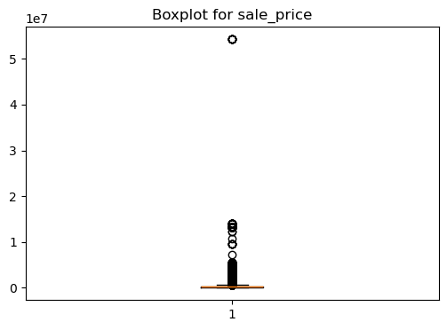

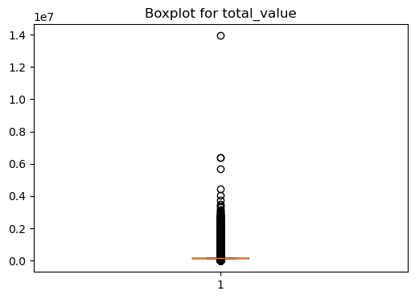

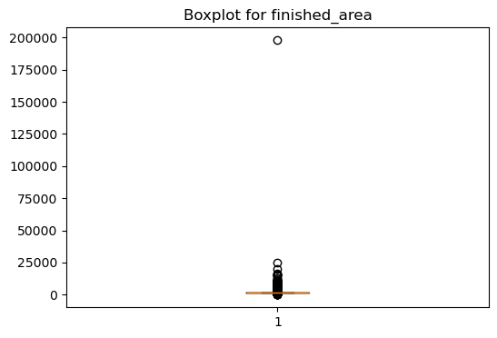

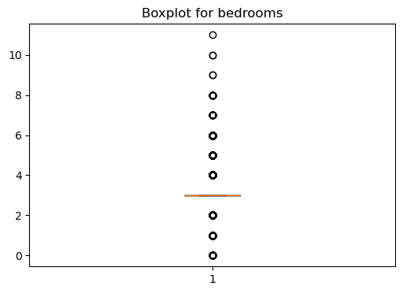

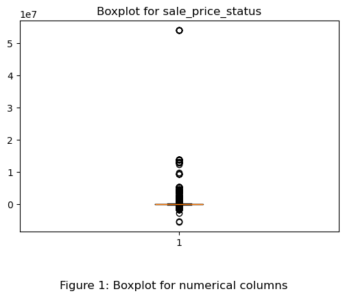

```python
# Visualize outliers for key columns
key_columns = ['sale_price', 'total_value', 'finished_area', 'bedrooms', 'sale_price_status']

for column in key_columns:
    plt.figure(figsize=(6, 4))
    plt.boxplot(nashville_data_cleaned[column].dropna())
    plt.title(f'Boxplot for {column}')
plt.figtext(0.5, -0.1, 'Figure 1: Boxplot for numerical columns',
                wrap=True, horizontalalignment='center', fontsize=12)
plt.show()
```

# Apply Capping (1st and 99th Percentiles)

```python
for column in key_columns:
    lower_limit = nashville_data_cleaned[column].quantile(0.01)
    upper_limit = nashville_data_cleaned[column].quantile(0.99)
    nashville_data_cleaned[column] = nashville_data_cleaned[column].clip(lower=lower_limit, upper=upper_limit)
    print(f"Capped {column}: Lower Limit = {lower_limit}, Upper Limit = {upper_limit}")
print("\nTable 3: Capped Data Ranges for Each Variable:")
```

```
Capped sale_price: Lower Limit = 24500.0, Upper Limit = 1935000.0
Capped total_value: Lower Limit = 15000.0, Upper Limit = 1013365.0000000001
Capped finished_area: Lower Limit = 781.0, Upper Limit = 5161.805974000002
Capped bedrooms: Lower Limit = 2.0, Upper Limit = 5.0
Capped sale_price_status: Lower Limit = -266000.0, Upper Limit = 1474157.0

Table 3: Capped Data Ranges for Each Variable:
```

# Visualize Outliers After Capping

```
Boxplots After Capping:
```

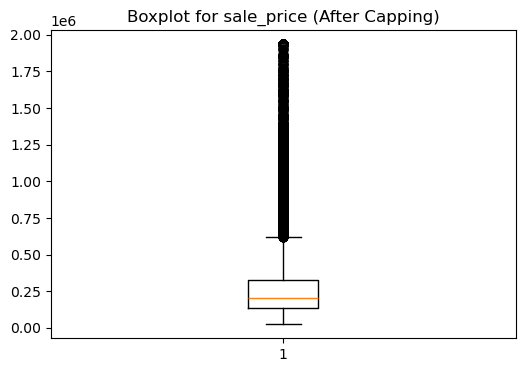

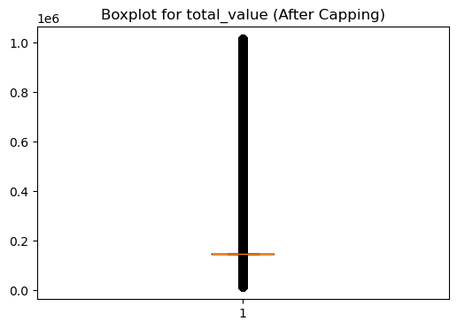

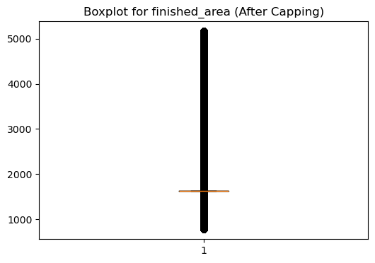

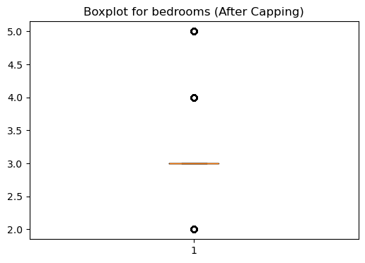

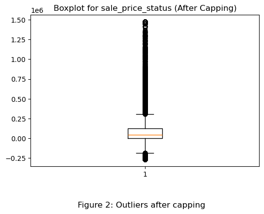

```python
print("\nBoxplots After Capping:")
for column in key_columns:
    plt.figure(figsize=(6, 4))
    plt.boxplot(nashville_data_cleaned[column].dropna())
    plt.title(f'Boxplot for {column} (After Capping)')
plt.figtext(0.5, -0.1, 'Figure 2: Outliers after capping',
                wrap=True, horizontalalignment='center', fontsize=12)
plt.show()
```

# Print the entire cleaned dataset

```python
print("Cleaned Dataset:")
print(nashville_data_cleaned)
print("\nTable 4: Cleaned Dataset:")
```

```
Cleaned Dataset:
       unnamed:_0.1  unnamed:_0         parcel_id           land_use  \
0                 0           0  105 03 0D 008.00  RESIDENTIAL CONDO
1                 1           1   105 11 0 080.00      SINGLE FAMILY
2                 2           2   118 03 0 130.00      SINGLE FAMILY
3                 3           3   119 01 0 479.00      SINGLE FAMILY
4                 4           4   119 05 0 186.00      SINGLE FAMILY
...             ...         ...               ...                ...
56631         56631       56631  093 13 0B 274.00  RESIDENTIAL CONDO
56632         56632       56632  093 13 0D 044.00  RESIDENTIAL CONDO
56633         56633       56633  093 13 0D 048.00  RESIDENTIAL CONDO
56634         56634       56634  093 13 0D 056.00  RESIDENTIAL CONDO
56635         56635       56635  093 13 0D 094.00  RESIDENTIAL CONDO

        property_address property_city  sale_date  sale_price  \
```

[output cut: 54 more lines]

# Q2: Task 2:

# Build a logistic regression model to accurately identify overpricing/underpricing and determine what is driving those prices.

# A2: Step 1: Create Target Variable

```python
nashville_data_cleaned['overpriced'] = (nashville_data_cleaned['sale_price_status'] > 0).astype(int)
```

# Step 2: Select Features and Target

```python
feature_columns = ['bedrooms', 'finished_area', 'year_built', 'land_use', 'foundation_type', 'grade']
X = nashville_data_cleaned[feature_columns]
X = pd.get_dummies(X, drop_first=True)  # One-hot encode categorical features
y = nashville_data_cleaned['overpriced']
```

# Step 3: Check for Multicollinearity

```python
# Ensure all features are numeric
X = pd.get_dummies(X, drop_first=True)

# Check and handle missing or invalid values
X = X.fillna(0)  # Replace NaN with 0
X = X.replace([np.inf, -np.inf], 0)  # Replace infinite values
X = X.astype(np.float64)  # Ensure all values are float64 for compatibility

# Calculate VIF
vif_data = pd.DataFrame()
vif_data['Feature'] = X.columns
vif_data['VIF'] = [variance_inflation_factor(X.values, i) for i in range(X.shape[1])]

print("Variance Inflation Factor (VIF):")
print(vif_data)
print("\nTable 5: Variance Inflation Factor (VIF):")
```

```
Variance Inflation Factor (VIF):
                           Feature           VIF
0                         bedrooms  6.784144e+01
1                    finished_area  3.245037e+01
2                       year_built  1.382726e+04
3                  land_use_CHURCH  1.117776e+01
4   land_use_CLUB/UNION HALL/LODGE           inf
..                             ...           ...
60                      grade_TCB            inf
61                      grade_TCC            inf
62                      grade_TCD            inf
63                      grade_TFC            inf
64                      grade_X     1.913090e+00

[65 rows x 2 columns]

Table 5: Variance Inflation Factor (VIF):
```

# Step 5: Drop Features with VIF = inf (Perfect Multicollinearity)

```python
redundant_features = vif_data[vif_data['VIF'] == float('inf')]['Feature']
X = X.drop(columns=redundant_features)
print(f"Removed redundant features: {list(redundant_features)}")
print("\nTable 6: Removed redundant features:")
```

```
Removed redundant features: ['land_use_CLUB/UNION HALL/LODGE', 'land_use_CONVENIENCE MARKET WITHOUT GAS', 'land_use_LIGHT MANUFACTURING', 'land_use_STRIP SHOPPING CENTER', 'land_use_TERMINAL/DISTRIBUTION WAREHOUSE', 'foundation_type_TYPICAL', 'grade_AAB ', 'grade_AAC ', 'grade_IDC ', 'grade_OFB ', '…

Table 6: Removed redundant features:
```

# Step 6: Recalculate VIF After Dropping Redundant Features

```python
# Define the VIF calculation function
def calculate_vif(data):
    vif_data = pd.DataFrame()
    vif_data['Feature'] = data.columns
    vif_data['VIF'] = [variance_inflation_factor(data.values, i) for i in range(data.shape[1])]
    return vif_data

vif_data = calculate_vif(X)
print("\nRecalculated VIF After Dropping Redundant Features:")
print(vif_data)
print("\nTable 7: Recalculated VIF After Dropping Redundant Features:")
```

```
Recalculated VIF After Dropping Redundant Features:
                                              Feature          VIF
0                                            bedrooms    67.270325
1                                       finished_area    32.197732
2                                          year_built  5075.535807
3                                     land_use_CHURCH     4.038033
4                                      land_use_CONDO    24.121116
5        land_use_CONDOMINIUM OFC  OR OTHER COM CONDO     4.211266
6                            land_use_DAY CARE CENTER     1.178997
7                   land_use_DORMITORY/BOARDING HOUSE     2.720075
8                                     land_use_DUPLEX   129.203539
9                                     land_use_FOREST     1.920107
10                                 land_use_GREENBELT     1.910627
11            land_use_GREENBELT/RES\r\nGRRENBELT/RES     1.273370
12  land_use_METRO OTHER THAN OFC, SCHOOL,HOSP, OR...     1.091750
```

[output cut: 34 more lines]

# Step 7: Drop Features with High VIF (Optional Threshold: VIF > 10)

```python
high_vif_features = vif_data[vif_data['VIF'] > 10]['Feature']
X = X.drop(columns=high_vif_features)
print(f"Removed high-VIF features: {list(high_vif_features)}")
print("\nTable 8: Removed high-VIF features:")
```

```
Removed high-VIF features: ['bedrooms', 'finished_area', 'year_built', 'land_use_CONDO', 'land_use_DUPLEX', 'land_use_RESIDENTIAL CONDO', 'land_use_SINGLE FAMILY', 'land_use_VACANT RES LAND', 'land_use_VACANT RESIDENTIAL LAND', 'land_use_ZERO LOT LINE', 'grade_C   ']

Table 8: Removed high-VIF features:
```

# Final VIF Calculation

```python
vif_data = calculate_vif(X)
print("\nFinal VIF After Removing High-VIF Features:")
print(vif_data)
print("\nTable 8: Final VIF After Removing High-VIF Features:")
```

```
Final VIF After Removing High-VIF Features:
                                              Feature       VIF
0                                     land_use_CHURCH  1.000730
1        land_use_CONDOMINIUM OFC  OR OTHER COM CONDO  1.000000
2                            land_use_DAY CARE CENTER  1.000170
3                   land_use_DORMITORY/BOARDING HOUSE  1.000255
4                                     land_use_FOREST  1.004072
5                                  land_use_GREENBELT  1.000026
6             land_use_GREENBELT/RES\r\nGRRENBELT/RES  1.000244
7   land_use_METRO OTHER THAN OFC, SCHOOL,HOSP, OR...  1.000000
8                                land_use_MOBILE HOME  1.000972
9                          land_use_MORTUARY/CEMETERY  1.000000
10                          land_use_NIGHTCLUB/LOUNGE  1.000000
11             land_use_NON-PROFIT CHARITABLE SERVICE  1.000240
12          land_use_OFFICE BLDG (ONE OR TWO STORIES)  1.000000
```

[output cut: 23 more lines]

# Step 8: Train-Test Split

```python
X_train, X_test, y_train, y_test = train_test_split(X, y, test_size=0.2, random_state=42)
```

# Step 9: Train Logistic Regression Model

```python
log_reg = LogisticRegression(max_iter=1000, random_state=42)
log_reg.fit(X_train, y_train)
```

```
LogisticRegression(max_iter=1000, random_state=42)
```

# Step 10: Evaluate Model

```python
y_pred = log_reg.predict(X_test)

print("\nModel Accuracy:")
print(f"{accuracy_score(y_test, y_pred):.2f}")

print("\nClassification Report:")
print(classification_report(y_test, y_pred))

print("\nConfusion Matrix:")
print(confusion_matrix(y_test, y_pred))
print("\nTable 9: Logistic Regression Model Performance Metrics")
```

```
Model Accuracy:
0.76

Classification Report:
              precision    recall  f1-score   support

           0       0.45      0.00      0.00      2766
           1       0.76      1.00      0.86      8562

    accuracy                           0.76     11328
   macro avg       0.61      0.50      0.43     11328
weighted avg       0.68      0.76      0.65     11328


Confusion Matrix:
[[   5 2761]
 [   6 8556]]

Table 9: Logistic Regression Model Performance Metrics
```

# Step 11: Interpret Coefficients

```python
coefficients = pd.DataFrame({
    'Feature': X_train.columns,
    'Coefficient': log_reg.coef_[0]
}).sort_values(by='Coefficient', ascending=False)

print("\nFeature Coefficients:")
print(coefficients)
print("\nTable 10: Feature Coefficients")
```

```
Feature Coefficients:
                                              Feature  Coefficient
1        land_use_CONDOMINIUM OFC  OR OTHER COM CONDO     1.088157
22                    land_use_VACANT COMMERCIAL LAND     0.815698
14                               land_use_PARKING LOT     0.546945
27                              foundation_type_PIERS     0.509050
4                                     land_use_FOREST     0.442079
6             land_use_GREENBELT/RES\r\nGRRENBELT/RES     0.132942
24                         land_use_VACANT RURAL LAND     0.121216
15                                 land_use_PARSONAGE     0.119116
2                            land_use_DAY CARE CENTER     0.118031
5                                  land_use_GREENBELT     0.081404
28                            foundation_type_PT BSMT     0.072692
7   land_use_METRO OTHER THAN OFC, SCHOOL,HOSP, OR...     0.061438
9                          land_use_MORTUARY/CEMETERY     0.061438
```

[output cut: 23 more lines]

# 1. Model Performance Analysis:

Although 76% accuracy is acceptable, the classification report and confusion matrix show that the two classes' performance is unbalanced

Class 1 (Overpriced): Precision: 76%, Recall: 100%. The model identifies overpriced properties well but over-predicts this class.

Dataset Imbalance: Poor performance for underpriced properties results from a large number of overpriced cases (Class 1) compared to underpriced cases (Class 0). This is probably the cause of the model's subpar performance on Class 0.

# 2. Feature Coefficients Analysis

Logistic regression coefficients indicate the influence of each feature on the likelihood of a property being overpriced:

Positive Coefficients: Features that increase the likelihood of overpricing. Negative Coefficients: Features that decrease the likelihood of overpricing.

A.)Key Features Driving Overpricing:

1.Land Use:

Properties in certain commercial and special-use categories are more likely to be overpriced:

2.Foundation Type:

3.Grade:

4.Forest and Greenbelt Land Uses:

B.)Key Features Driving Underpricing:

1.Land Use:

land_use_CHURCH (-1.097), land_use_MOBILE HOME (-1.401), and land_use_RESIDENTIAL COMBO/MISC (-0.672) are associated with underpricing.

2.Grade:

Properties with grade_X (-1.107) and grade_E (-0.962) are significantly underpriced.

3.Office and Restaurant Properties:

land_use_OFFICE BLDG (ONE OR TWO STORIES) (-0.381), land_use_RESTURANT/CAFETERIA (-0.381), and similar commercial properties are underpriced.

# 3.Recommendations for Identifying Overpriced/Underpriced Properties

A.) Overpriced Properties:

Look for properties with:

Land Use: Commercial categories like CONDOMINIUM OFC, VACANT COMMERCIAL LAND, and PARKING LOT.

Foundation Type: Properties with PIERS.

B.) Underpriced Properties:

Look for properties with:

Land Use: Churches, mobile homes, or residential combination types.

Grade: Extremely low grades like X or E.

Commercial Types: Office buildings and restaurants may represent investment opportunities.

# Q3: Task 3:

# Build a decision tree model.

# A3: Train Decision Tree Model

```python
# Initialize Decision Tree Classifier
decision_tree = DecisionTreeClassifier(random_state=42, max_depth=5, min_samples_split=20)
decision_tree.fit(X_train, y_train)
```

```
DecisionTreeClassifier(max_depth=5, min_samples_split=20, random_state=42)
```

# Evaluate the Model

```python
y_pred = decision_tree.predict(X_test)

print("\nModel Accuracy:")
print(f"{accuracy_score(y_test, y_pred):.2f}")

print("\nClassification Report:")
print(classification_report(y_test, y_pred))

print("\nConfusion Matrix:")
print(confusion_matrix(y_test, y_pred))
print("\nTable 11: Decision Tree Model Performance Metrics")
```

```
Model Accuracy:
0.76

Classification Report:
              precision    recall  f1-score   support

           0       0.56      0.01      0.03      2766
           1       0.76      1.00      0.86      8562

    accuracy                           0.76     11328
   macro avg       0.66      0.50      0.44     11328
weighted avg       0.71      0.76      0.66     11328


Confusion Matrix:
[[  37 2729]
 [  29 8533]]

Table 11: Decision Tree Model Performance Metrics
```

# Visualize the Decision Tree

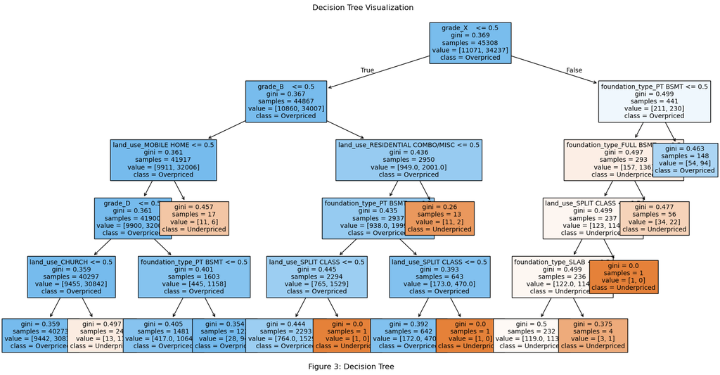

```python
plt.figure(figsize=(20, 10))
plot_tree(
    decision_tree,
    feature_names=X.columns.tolist(),  # Convert to a list
    class_names=["Underpriced", "Overpriced"],
    filled=True,
    fontsize=10
)
plt.title("Decision Tree Visualization")
plt.figtext(0.5, 0.1, 'Figure 3: Decision Tree',
                wrap=True, horizontalalignment='center', fontsize=12)
plt.show()
```

# Q4: Task 4:

# Build a Random Forest model.

# A4: Train Random Forest Model

```python
# Initialize Random Forest Classifier
random_forest = RandomForestClassifier(n_estimators=100, max_depth=10, random_state=42)
random_forest.fit(X_train, y_train)
```

```
RandomForestClassifier(max_depth=10, random_state=42)
```

# Evaluate the Model

```python
y_pred = random_forest.predict(X_test)

print("\nModel Accuracy:")
print(f"{accuracy_score(y_test, y_pred):.2f}")

print("\nClassification Report:")
print(classification_report(y_test, y_pred))

print("\nConfusion Matrix:")
conf_matrix = confusion_matrix(y_test, y_pred)
print(conf_matrix)
print("\nTable 12: Random Forest Model Performance Metrics")
```

```
Model Accuracy:
0.76

Classification Report:
              precision    recall  f1-score   support

           0       0.77      0.00      0.01      2766
           1       0.76      1.00      0.86      8562

    accuracy                           0.76     11328
   macro avg       0.76      0.50      0.43     11328
weighted avg       0.76      0.76      0.65     11328


Confusion Matrix:
[[  10 2756]
 [   3 8559]]

Table 12: Random Forest Model Performance Metrics
```

# Visualize Confusion Matrix

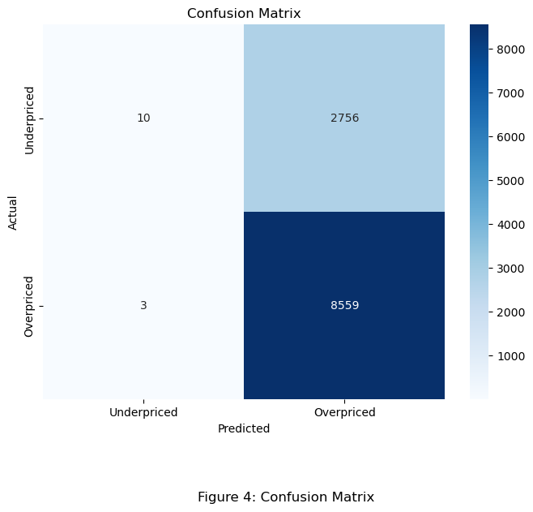

```python
plt.figure(figsize=(8, 6))
sns.heatmap(conf_matrix, annot=True, fmt="d", cmap="Blues", xticklabels=["Underpriced", "Overpriced"], yticklabels=["Underpriced", "Overpriced"])
plt.title("Confusion Matrix")
plt.xlabel("Predicted")
plt.ylabel("Actual")
plt.figtext(0.5, -0.1, 'Figure 4: Confusion Matrix',
                wrap=True, horizontalalignment='center', fontsize=12)
plt.show()
```

# Feature Importance

```python
feature_importances = pd.DataFrame({
    'Feature': X.columns,
    'Importance': random_forest.feature_importances_
}).sort_values(by='Importance', ascending=False)

print("\nFeature Importances:")
print(feature_importances)
print("\nTable 13: Feature Importances")
```

```
Feature Importances:
                                              Feature  Importance
33                                         grade_X       0.325965
30                                         grade_B       0.244025
28                            foundation_type_PT BSMT    0.060030
17                    land_use_RESIDENTIAL COMBO/MISC    0.039587
8                                land_use_MOBILE HOME    0.038607
0                                     land_use_CHURCH    0.036902
32                                         grade_E       0.036760
31                                         grade_D       0.034976
29                               foundation_type_SLAB    0.034242
26                          foundation_type_FULL BSMT    0.029514
21                                   land_use_TRIPLEX    0.024186
1        land_use_CONDOMINIUM OFC  OR OTHER COM CONDO    0.014162
20                               land_use_SPLIT CLASS    0.011826
```

[output cut: 23 more lines]

# Plot Feature Importance

```
) missing from font(s) DejaVu Sans.ackages\IPython\core\pylabtools.py:170: UserWarning: Glyph 13 (
  fig.canvas.print_figure(bytes_io, **kw)
```

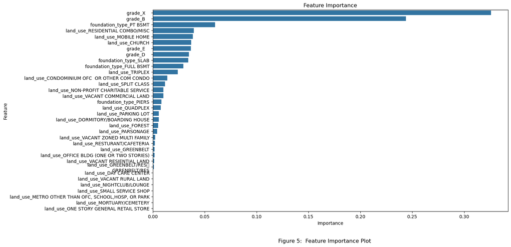

```python
plt.figure(figsize=(14, 8))
sns.barplot(x="Importance", y="Feature", data=feature_importances)
plt.title("Feature Importance")
plt.figtext(0.5, -0.01, 'Figure 5:  Feature Importance Plot',
                wrap=True, horizontalalignment='center', fontsize=12)
plt.show()
```

# Q5: Task 5:

# Build a Gradient Boost model.

# A5: Train Gradient Boosting Model

```python
# Initialize Gradient Boosting Classifier
gradient_boost = GradientBoostingClassifier(
    n_estimators=100,  # Number of trees
    learning_rate=0.1,  # Learning rate
    max_depth=5,       # Maximum depth of trees
    random_state=42
)
gradient_boost.fit(X_train, y_train)
```

```
GradientBoostingClassifier(max_depth=5, random_state=42)
```

# Evaluate the Model

```python
y_pred = gradient_boost.predict(X_test)

print("\nModel Accuracy:")
print(f"{accuracy_score(y_test, y_pred):.2f}")

print("\nClassification Report:")
print(classification_report(y_test, y_pred))
print("\nTable 14: Gradient Boost Model Performance Report")
```

```
Model Accuracy:
0.76

Classification Report:
              precision    recall  f1-score   support

           0       0.55      0.01      0.03      2766
           1       0.76      1.00      0.86      8562

    accuracy                           0.76     11328
   macro avg       0.65      0.51      0.44     11328
weighted avg       0.71      0.76      0.66     11328


Table 14: Gradient Boost Model Performance Report
```

# Visualize Confusion Matrix

[figure not shown]

```python
plt.figure(figsize=(8, 6))
sns.heatmap(conf_matrix, annot=True, fmt="d", cmap="Blues", xticklabels=["Underpriced", "Overpriced"], yticklabels=["Underpriced", "Overpriced"])
plt.title("Confusion Matrix")
plt.xlabel("Predicted")
plt.ylabel("Actual")
plt.figtext(0.5, -0.01, 'Figure 6:  Confusion Matrix',
                wrap=True, horizontalalignment='center', fontsize=12)
plt.show()
```

# Plot Feature Importance

```
) missing from font(s) DejaVu Sans.ackages\IPython\core\pylabtools.py:170: UserWarning: Glyph 13 (
  fig.canvas.print_figure(bytes_io, **kw)
```

[figure not shown]

```python
plt.figure(figsize=(12, 8))
sns.barplot(x="Importance", y="Feature", data=feature_importances)
plt.title("Feature Importance")
plt.figtext(0.5, -0.01, 'Figure 7:  Feature Importance Plot',
                wrap=True, horizontalalignment='center', fontsize=12)
plt.show()
```

```python
# Save cleaned data to a CSV file
nashville_data_cleaned.to_csv('nashville_data_cleaned.csv', index=False)
print("Cleaned data saved successfully.")
```

```
Cleaned data saved successfully.
```

# Q6: Task 6:

# Build a Neural Network model.

# A6: Load the cleaned dataset

```python
import pandas as pd

# Load the cleaned dataset
nashville_data_cleaned = pd.read_csv('nashville_data_cleaned.csv')
print("Cleaned data loaded successfully.")
```

```
Cleaned data loaded successfully.
```

```python
import tensorflow as tf
from tensorflow.keras.models import Sequential
from tensorflow.keras.layers import Dense, Dropout
from sklearn.model_selection import train_test_split
from sklearn.preprocessing import StandardScaler
from sklearn.metrics import accuracy_score, classification_report, confusion_matrix
import matplotlib.pyplot as plt
import seaborn as sns
```

# Prepare Features and Target

```python
feature_columns = ['bedrooms', 'finished_area', 'year_built', 'land_use', 'foundation_type', 'grade']
X = nashville_data_cleaned[feature_columns]
X = pd.get_dummies(X, drop_first=True)  # One-hot encode categorical features
y = nashville_data_cleaned['overpriced']
```

# Normalize Features

```python
scaler = StandardScaler()
X = scaler.fit_transform(X)
```

# Train-Test Split

```python
X_train, X_test, y_train, y_test = train_test_split(X, y, test_size=0.2, random_state=42)
```

# Build Neural Network Model

```python
model = Sequential([
    Dense(128, input_dim=X_train.shape[1], activation='relu'),  # Input Layer + Hidden Layer 1
    Dropout(0.2),  # Regularization
    Dense(64, activation='relu'),  # Hidden Layer 2
    Dropout(0.2),
    Dense(32, activation='relu'),  # Hidden Layer 3
    Dense(1, activation='sigmoid')  # Output Layer for binary classification
])
```

```
C:\Users\Mohit Saini\AppData\Local\Programs\Python\Python312\Lib\site-packages\keras\src\layers\core\dense.py:87: UserWarning: Do not pass an `input_shape`/`input_dim` argument to a layer. When using Sequential models, prefer using an `Input(shape)` object as the first layer in the model instead.
  super().__init__(activity_regularizer=activity_regularizer, **kwargs)
```

# Compile the Model

```python
model.compile(optimizer='adam', loss='binary_crossentropy', metrics=['accuracy'])
```

# Train the Model

```python
history = model.fit(
    X_train, y_train,
    validation_data=(X_test, y_test),
    epochs=50,
    batch_size=32,
    verbose=1
)
print("\nTable 15: Neural Network Training and Validation Performance History")
```

```
1416/1416 ━━━━━━━━━━━━━━━━━━━━ 7s 3ms/step - accuracy: 0.7532 - loss: 0.5606 - val_accuracy: 0.7598 - val_loss: 0.5381
1416/1416 ━━━━━━━━━━━━━━━━━━━━ 5s 3ms/step - accuracy: 0.7614 - loss: 0.5392 - val_accuracy: 0.7600 - val_loss: 0.5378
1416/1416 ━━━━━━━━━━━━━━━━━━━━ 5s 3ms/step - accuracy: 0.7610 - loss: 0.5383 - val_accuracy: 0.7614 - val_loss: 0.5362
1416/1416 ━━━━━━━━━━━━━━━━━━━━ 5s 3ms/step - accuracy: 0.7631 - loss: 0.5358 - val_accuracy: 0.7610 - val_loss: 0.5366
1416/1416 ━━━━━━━━━━━━━━━━━━━━ 5s 3ms/step - accuracy: 0.7599 - loss: 0.5381 - val_accuracy: 0.7614 - val_loss: 0.5356
1416/1416 ━━━━━━━━━━━━━━━━━━━━ 5s 3ms/step - accuracy: 0.7630 - loss: 0.5342 - val_accuracy: 0.7616 - val_loss: 0.5375
1416/1416 ━━━━━━━━━━━━━━━━━━━━ 5s 3ms/step - accuracy: 0.7625 - loss: 0.5363 - val_accuracy: 0.7609 - val_loss: 0.5365
1416/1416 ━━━━━━━━━━━━━━━━━━━━ 5s 3ms/step - accuracy: 0.7618 - loss: 0.5354 - val_accuracy: 0.7607 - val_loss: 0.5363
1416/1416 ━━━━━━━━━━━━━━━━━━━━ 4s 3ms/step - accuracy: 0.7619 - loss: 0.5352 - val_accuracy: 0.7616 - val_loss: 0.5355
1416/1416 ━━━━━━━━━━━━━━━━━━━━ 5s 3ms/step - accuracy: 0.7642 - loss: 0.5325 - val_accuracy: 0.7613 - val_loss: 0.5357
1416/1416 ━━━━━━━━━━━━━━━━━━━━ 5s 3ms/step - accuracy: 0.7673 - loss: 0.5295 - val_accuracy: 0.7610 - val_loss: 0.5375
1416/1416 ━━━━━━━━━━━━━━━━━━━━ 5s 3ms/step - accuracy: 0.7620 - loss: 0.5340 - val_accuracy: 0.7616 - val_loss: 0.5384
1416/1416 ━━━━━━━━━━━━━━━━━━━━ 5s 3ms/step - accuracy: 0.7670 - loss: 0.5285 - val_accuracy: 0.7622 - val_loss: 0.5379
1416/1416 ━━━━━━━━━━━━━━━━━━━━ 5s 3ms/step - accuracy: 0.7635 - loss: 0.5328 - val_accuracy: 0.7616 - val_loss: 0.5395
1416/1416 ━━━━━━━━━━━━━━━━━━━━ 5s 3ms/step - accuracy: 0.7643 - loss: 0.5308 - val_accuracy: 0.7613 - val_loss: 0.5369
1416/1416 ━━━━━━━━━━━━━━━━━━━━ 4s 3ms/step - accuracy: 0.7596 - loss: 0.5365 - val_accuracy: 0.7610 - val_loss: 0.5384
1416/1416 ━━━━━━━━━━━━━━━━━━━━ 5s 3ms/step - accuracy: 0.7645 - loss: 0.5321 - val_accuracy: 0.7612 - val_loss: 0.5364
1416/1416 ━━━━━━━━━━━━━━━━━━━━ 4s 3ms/step - accuracy: 0.7626 - loss: 0.5333 - val_accuracy: 0.7612 - val_loss: 0.5363
1416/1416 ━━━━━━━━━━━━━━━━━━━━ 4s 3ms/step - accuracy: 0.7603 - loss: 0.5365 - val_accuracy: 0.7613 - val_loss: 0.5374
1416/1416 ━━━━━━━━━━━━━━━━━━━━ 5s 3ms/step - accuracy: 0.7623 - loss: 0.5348 - val_accuracy: 0.7610 - val_loss: 0.5381
1416/1416 ━━━━━━━━━━━━━━━━━━━━ 5s 3ms/step - accuracy: 0.7603 - loss: 0.5353 - val_accuracy: 0.7615 - val_loss: 0.5398
1416/1416 ━━━━━━━━━━━━━━━━━━━━ 4s 3ms/step - accuracy: 0.7658 - loss: 0.5294 - val_accuracy: 0.7616 - val_loss: 0.5370
1416/1416 ━━━━━━━━━━━━━━━━━━━━ 5s 3ms/step - accuracy: 0.7641 - loss: 0.5320 - val_accuracy: 0.7616 - val_loss: 0.5383
1416/1416 ━━━━━━━━━━━━━━━━━━━━ 5s 3ms/step - accuracy: 0.7630 - loss: 0.5324 - val_accuracy: 0.7611 - val_loss: 0.5410
1416/1416 ━━━━━━━━━━━━━━━━━━━━ 5s 3ms/step - accuracy: 0.7633 - loss: 0.5325 - val_accuracy: 0.7617 - val_loss: 0.5407
1416/1416 ━━━━━━━━━━━━━━━━━━━━ 5s 3ms/step - accuracy: 0.7675 - loss: 0.5285 - val_accuracy: 0.7612 - val_loss: 0.5387
1416/1416 ━━━━━━━━━━━━━━━━━━━━ 5s 4ms/step - accuracy: 0.7633 - loss: 0.5331 - val_accuracy: 0.7620 - val_loss: 0.5381
1416/1416 ━━━━━━━━━━━━━━━━━━━━ 5s 3ms/step - accuracy: 0.7645 - loss: 0.5318 - val_accuracy: 0.7617 - val_loss: 0.5378
1416/1416 ━━━━━━━━━━━━━━━━━━━━ 4s 3ms/step - accuracy: 0.7628 - loss: 0.5325 - val_accuracy: 0.7614 - val_loss: 0.5366
1416/1416 ━━━━━━━━━━━━━━━━━━━━ 4s 3ms/step - accuracy: 0.7639 - loss: 0.5312 - val_accuracy: 0.7628 - val_loss: 0.5371
1416/1416 ━━━━━━━━━━━━━━━━━━━━ 5s 3ms/step - accuracy: 0.7666 - loss: 0.5285 - val_accuracy: 0.7610 - val_loss: 0.5359
1416/1416 ━━━━━━━━━━━━━━━━━━━━ 5s 3ms/step - accuracy: 0.7650 - loss: 0.5292 - val_accuracy: 0.7610 - val_loss: 0.5351
1416/1416 ━━━━━━━━━━━━━━━━━━━━ 5s 3ms/step - accuracy: 0.7675 - loss: 0.5284 - val_accuracy: 0.7607 - val_loss: 0.5350
1416/1416 ━━━━━━━━━━━━━━━━━━━━ 5s 3ms/step - accuracy: 0.7619 - loss: 0.5337 - val_accuracy: 0.7614 - val_loss: 0.5359
1416/1416 ━━━━━━━━━━━━━━━━━━━━ 5s 3ms/step - accuracy: 0.7652 - loss: 0.5291 - val_accuracy: 0.7614 - val_loss: 0.5365
1416/1416 ━━━━━━━━━━━━━━━━━━━━ 5s 3ms/step - accuracy: 0.7690 - loss: 0.5256 - val_accuracy: 0.7614 - val_loss: 0.5368
1416/1416 ━━━━━━━━━━━━━━━━━━━━ 5s 3ms/step - accuracy: 0.7629 - loss: 0.5295 - val_accuracy: 0.7614 - val_loss: 0.5358
1416/1416 ━━━━━━━━━━━━━━━━━━━━ 4s 3ms/step - accuracy: 0.7652 - loss: 0.5288 - val_accuracy: 0.7617 - val_loss: 0.5382
1416/1416 ━━━━━━━━━━━━━━━━━━━━ 4s 3ms/step - accuracy: 0.7634 - loss: 0.5310 - val_accuracy: 0.7616 - val_loss: 0.5389
1416/1416 ━━━━━━━━━━━━━━━━━━━━ 5s 3ms/step - accuracy: 0.7636 - loss: 0.5316 - val_accuracy: 0.7618 - val_loss: 0.5360
1416/1416 ━━━━━━━━━━━━━━━━━━━━ 5s 4ms/step - accuracy: 0.7709 - loss: 0.5235 - val_accuracy: 0.7623 - val_loss: 0.5377
1416/1416 ━━━━━━━━━━━━━━━━━━━━ 5s 3ms/step - accuracy: 0.7614 - loss: 0.5326 - val_accuracy: 0.7614 - val_loss: 0.5414
1416/1416 ━━━━━━━━━━━━━━━━━━━━ 4s 3ms/step - accuracy: 0.7659 - loss: 0.5293 - val_accuracy: 0.7617 - val_loss: 0.5374
1416/1416 ━━━━━━━━━━━━━━━━━━━━ 5s 3ms/step - accuracy: 0.7650 - loss: 0.5279 - val_accuracy: 0.7616 - val_loss: 0.5364
1416/1416 ━━━━━━━━━━━━━━━━━━━━ 5s 3ms/step - accuracy: 0.7629 - loss: 0.5310 - val_accuracy: 0.7615 - val_loss: 0.5371
1416/1416 ━━━━━━━━━━━━━━━━━━━━ 5s 3ms/step - accuracy: 0.7659 - loss: 0.5298 - val_accuracy: 0.7617 - val_loss: 0.5351
1416/1416 ━━━━━━━━━━━━━━━━━━━━ 4s 3ms/step - accuracy: 0.7619 - loss: 0.5329 - val_accuracy: 0.7622 - val_loss: 0.5382
1416/1416 ━━━━━━━━━━━━━━━━━━━━ 5s 3ms/step - accuracy: 0.7644 - loss: 0.5304 - val_accuracy: 0.7611 - val_loss: 0.5378
1416/1416 ━━━━━━━━━━━━━━━━━━━━ 5s 3ms/step - accuracy: 0.7651 - loss: 0.5295 - val_accuracy: 0.7615 - val_loss: 0.5364
1416/1416 ━━━━━━━━━━━━━━━━━━━━ 4s 3ms/step - accuracy: 0.7654 - loss: 0.5281 - val_accuracy: 0.7610 - val_loss: 0.5355

Table 15: Neural Network Training and Validation Performance History
```

# Evaluate the Model

```python
y_pred = (model.predict(X_test) > 0.5).astype(int)

print("\nModel Accuracy:")
print(f"{accuracy_score(y_test, y_pred):.2f}")

print("\nClassification Report:")
print(classification_report(y_test, y_pred))

print("\nConfusion Matrix:")
conf_matrix = confusion_matrix(y_test, y_pred)
print(conf_matrix)
print("\nTable 16: Neural Network model Evaluation")
```

```
354/354 ━━━━━━━━━━━━━━━━━━━━ 1s 1ms/step

Model Accuracy:
0.76

Classification Report:
              precision    recall  f1-score   support

           0       0.82      0.03      0.05      2766
           1       0.76      1.00      0.86      8562

    accuracy                           0.76     11328
   macro avg       0.79      0.51      0.46     11328
weighted avg       0.78      0.76      0.67     11328


Confusion Matrix:
[[  75 2691]
 [  16 8546]]

Table 16: Neural Network model Evaluation
```

# Visualize Training History

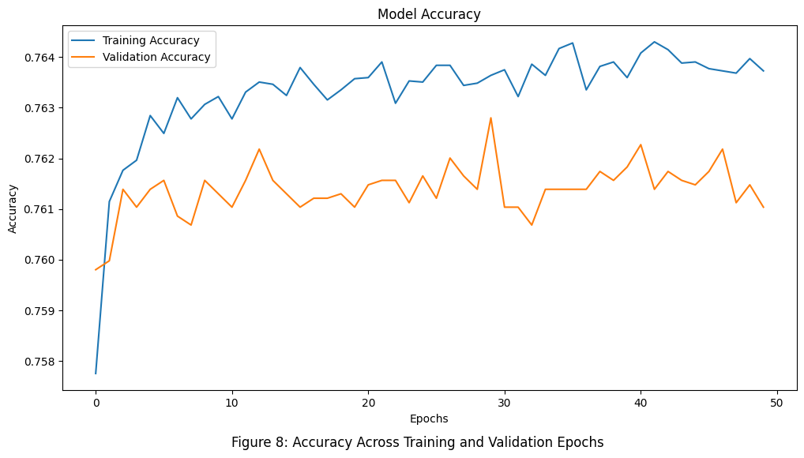

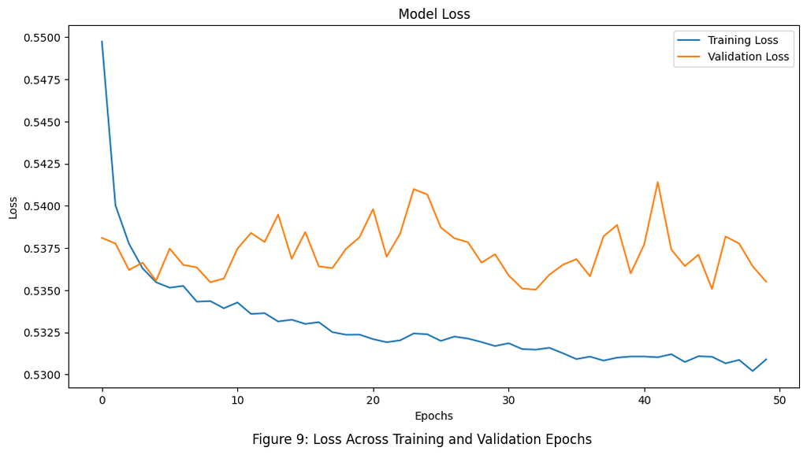

```python
plt.figure(figsize=(12, 6))
plt.plot(history.history['accuracy'], label='Training Accuracy')
plt.plot(history.history['val_accuracy'], label='Validation Accuracy')
plt.title('Model Accuracy')
plt.xlabel('Epochs')
plt.ylabel('Accuracy')
plt.legend()
plt.figtext(0.5, -0.01, 'Figure 8: Accuracy Across Training and Validation Epochs',
           wrap=True, horizontalalignment='center', fontsize=12)
plt.show()

plt.figure(figsize=(12, 6))
plt.plot(history.history['loss'], label='Training Loss')
plt.plot(history.history['val_loss'], label='Validation Loss')
plt.title('Model Loss')
plt.xlabel('Epochs')
plt.ylabel('Loss')
plt.legend()
plt.figtext(0.5, -0.01, 'Figure 9: Loss Across Training and Validation Epochs',
           wrap=True, horizontalalignment='center', fontsize=12)
plt.show()
```